# Motivation biases face and scene selective neural activity during visual categorization.

```r
# Clear workspace
rm(list = ls())

# Load helper functions
source('helper_functions.R')

# Import libraries
packages = c("MASS","sfsmisc","tidyr","dplyr","ggplot2","lme4","lmerTest","Hmisc","car","lmtest","Rarity","cowplot")
ipak(packages)

# Redo long calculations
redo_calc = 0;
```

#### Load Data

```r
# Read data
AllData = read.csv("../data/AllData.csv")

# Convert to factors
AllData$Sub = as.factor(AllData$Sub)
AllData$Pred = as.factor(AllData$Pred)
AllData$Want2See = as.factor(AllData$Want2See)
AllData$Con_Rev = factor(AllData$Con, levels = c('Coop','Comp'))
AllData_ValidTrials = filter(AllData, !(is.na(Choice)))

# Load psychometric results (see Fig. 2 code)
load("long_calc/ConditionxBet.Rda")
```

#### Motivation biases category selective neural activity during visual categorization

```r
## Median split participants
intSlope = unlist(coef(res)$Sub$`ConCoop:Pred1`)
SubBias = as.data.frame(intSlope)
SubBias$Sub = unique(AllData$Sub)
SubBias$medianBehave = SubBias$intSlope > median(SubBias$intSlope)

BiasedData =  subset(AllData_ValidTrials, Sub %in% SubBias$Sub[SubBias$medianBehav == "TRUE"])
UnbiasedData = subset(AllData_ValidTrials, Sub %in% SubBias$Sub[SubBias$medianBehav == "FALSE"])

if (redo_calc) {
  res.prob = lmer(Prob ~ Cat_n_z  + Con * Pred + (Con * Pred |Sub), AllData_ValidTrials)

  res.prob.bias = lmer(Prob ~ Cat_n_z  + Con * Pred + (Con * Pred |Sub), BiasedData)
  res.prob.unbias = lmer(Prob ~ Cat_n_z  + Con * Pred + (Con * Pred |Sub), UnbiasedData)

  save(res.prob, res.prob.bias, res.prob.unbias, file="long_calc/NeuralBias.Rda")
} else {
  load("long_calc/NeuralBias.Rda")
  }

AllData_ValidTrials = full_join(AllData_ValidTrials, SubBias)
summary(res.prob)
```

```
## Linear mixed model fit by REML. t-tests use Satterthwaite's method [
## lmerModLmerTest]
## Formula: Prob ~ Cat_n_z + Con * Pred + (Con * Pred | Sub)
##    Data: AllData_ValidTrials
##
## REML criterion at convergence: 2799.5
##
## Scaled residuals:
##     Min      1Q  Median      3Q     Max
## -2.6764 -0.9217 -0.0028  0.9537  2.8576
##
## Random effects:
##  Groups   Name          Variance  Std.Dev.  Corr
##  Sub      (Intercept)   7.808e-16 2.794e-08
##           ConCoop       1.360e-14 1.166e-07 -1.00
##           Pred1         8.195e-15 9.053e-08 -0.52  0.52
##           ConCoop:Pred1 1.153e-13 3.395e-07  0.78 -0.78 -0.67
##  Residual               1.047e-01 3.235e-01
## Number of obs: 4761, groups:  Sub, 30
##
## Fixed effects:
##                 Estimate Std. Error         df t value Pr(>|t|)
## (Intercept)    5.048e-01  9.394e-03  4.756e+03  53.737   <2e-16 ***
## Cat_n_z        1.206e-01  4.682e-03  4.756e+03  25.765   <2e-16 ***
## ConCoop       -2.132e-02  1.326e-02  4.756e+03  -1.607   0.1081
## Pred1         -2.134e-02  1.327e-02  4.756e+03  -1.608   0.1079
## ConCoop:Pred1  3.851e-02  1.876e-02  4.756e+03   2.053   0.0401 *
## ---
## Signif. codes:  0 '***' 0.001 '**' 0.01 '*' 0.05 '.' 0.1 ' ' 1
##
## Correlation of Fixed Effects:
##             (Intr) Ct_n_z ConCop Pred1
## Cat_n_z      0.002
## ConCoop     -0.708 -0.002
## Pred1       -0.708 -0.001  0.501
## ConCop:Prd1  0.501  0.001 -0.707 -0.707
```

```r
res.int.con = lmer(Prob ~ Cat_n_z  + Con * Pred * intSlope + (Con * Pred|Sub), AllData_ValidTrials)
summary(res.int.con)
```

```
## Linear mixed model fit by REML. t-tests use Satterthwaite's method [
## lmerModLmerTest]
## Formula: Prob ~ Cat_n_z + Con * Pred * intSlope + (Con * Pred | Sub)
##    Data: AllData_ValidTrials
##
## REML criterion at convergence: 2818.5
##
## Scaled residuals:
##      Min       1Q   Median       3Q      Max
## -2.71634 -0.92087 -0.01022  0.93589  2.89666
##
## Random effects:
##  Groups   Name          Variance  Std.Dev.  Corr
##  Sub      (Intercept)   0.000e+00 0.000e+00
##           ConCoop       4.261e-15 6.528e-08   NaN
##           Pred1         3.434e-16 1.853e-08   NaN  0.97
##           ConCoop:Pred1 1.364e-14 1.168e-07   NaN -0.82 -0.91
##  Residual               1.045e-01 3.233e-01
## Number of obs: 4761, groups:  Sub, 30
##
## Fixed effects:
##                          Estimate Std. Error         df t value Pr(>|t|)
## (Intercept)             4.952e-01  1.159e-02  4.752e+03  42.707  < 2e-16
## Cat_n_z                 1.206e-01  4.678e-03  4.752e+03  25.785  < 2e-16
## ConCoop                -1.012e-03  1.636e-02  4.752e+03  -0.062 0.950675
## Pred1                  -1.753e-03  1.637e-02  4.752e+03  -0.107 0.914711
## intSlope                1.190e-02  8.422e-03  4.752e+03   1.413 0.157742
## ConCoop:Pred1          -7.180e-03  2.312e-02  4.752e+03  -0.311 0.756186
## ConCoop:intSlope       -2.522e-02  1.191e-02  4.752e+03  -2.118 0.034207
## Pred1:intSlope         -2.433e-02  1.192e-02  4.752e+03  -2.040 0.041411
## ConCoop:Pred1:intSlope  5.686e-02  1.685e-02  4.752e+03   3.374 0.000747
##
## (Intercept)            ***
## Cat_n_z                ***
## ConCoop
## Pred1
## intSlope
## ConCoop:Pred1
## ConCoop:intSlope       *
## Pred1:intSlope         *
## ConCoop:Pred1:intSlope ***
## ---
## Signif. codes:  0 '***' 0.001 '**' 0.01 '*' 0.05 '.' 0.1 ' ' 1
##
## Correlation of Fixed Effects:
##             (Intr) Ct_n_z ConCop Pred1  intSlp CnC:P1 CnCp:S Prd1:S
## Cat_n_z      0.001
## ConCoop     -0.709 -0.001
## Pred1       -0.708 -0.001  0.502
## intSlope    -0.587  0.001  0.416  0.416
## ConCop:Prd1  0.501  0.001 -0.707 -0.708 -0.294
## ConCp:ntSlp  0.415  0.000 -0.586 -0.294 -0.707  0.415
## Pred1:ntSlp  0.415 -0.001 -0.294 -0.587 -0.706  0.415  0.499
## CnCp:Prd1:S -0.293  0.000  0.414  0.415  0.500 -0.586 -0.707 -0.708
```

```r
# High Bias participants
summary(res.prob.bias)
```

```
## Linear mixed model fit by REML. t-tests use Satterthwaite's method [
## lmerModLmerTest]
## Formula: Prob ~ Cat_n_z + Con * Pred + (Con * Pred | Sub)
##    Data: BiasedData
##
## REML criterion at convergence: 1423.6
##
## Scaled residuals:
##      Min       1Q   Median       3Q      Max
## -2.56216 -0.92162 -0.02117  0.95604  2.85701
##
## Random effects:
##  Groups   Name          Variance  Std.Dev.  Corr
##  Sub      (Intercept)   1.373e-15 3.705e-08
##           ConCoop       6.755e-15 8.219e-08 -1.00
##           Pred1         7.100e-15 8.426e-08 -0.17  0.17
##           ConCoop:Pred1 6.604e-14 2.570e-07  0.30 -0.30 -0.87
##  Residual               1.051e-01 3.241e-01
## Number of obs: 2383, groups:  Sub, 15
##
## Fixed effects:
##                 Estimate Std. Error         df t value Pr(>|t|)
## (Intercept)    5.108e-01  1.328e-02  2.378e+03  38.473  < 2e-16 ***
## Cat_n_z        1.227e-01  6.642e-03  2.378e+03  18.476  < 2e-16 ***
## ConCoop       -3.402e-02  1.876e-02  2.378e+03  -1.813  0.06992 .
## Pred1         -3.244e-02  1.878e-02  2.378e+03  -1.728  0.08421 .
## ConCoop:Pred1  7.861e-02  2.656e-02  2.378e+03   2.960  0.00311 **
## ---
## Signif. codes:  0 '***' 0.001 '**' 0.01 '*' 0.05 '.' 0.1 ' ' 1
##
## Correlation of Fixed Effects:
##             (Intr) Ct_n_z ConCop Pred1
## Cat_n_z      0.002
## ConCoop     -0.708 -0.001
## Pred1       -0.707 -0.002  0.500
## ConCop:Prd1  0.500  0.001 -0.706 -0.707
```

```r
# Low Bias Participants
summary(res.prob.unbias)
```

```
## Linear mixed model fit by REML. t-tests use Satterthwaite's method [
## lmerModLmerTest]
## Formula: Prob ~ Cat_n_z + Con * Pred + (Con * Pred | Sub)
##    Data: UnbiasedData
##
## REML criterion at convergence: 1400.7
##
## Scaled residuals:
##      Min       1Q   Median       3Q      Max
## -2.67524 -0.92355  0.01745  0.93720  2.69276
##
## Random effects:
##  Groups   Name          Variance  Std.Dev.  Corr
##  Sub      (Intercept)   3.221e-14 1.795e-07
##           ConCoop       9.038e-15 9.507e-08 -1.00
##           Pred1         2.245e-13 4.738e-07 -0.98  0.98
##           ConCoop:Pred1 1.599e-13 3.999e-07  0.94 -0.94 -0.97
##  Residual               1.042e-01 3.228e-01
## Number of obs: 2378, groups:  Sub, 15
##
## Fixed effects:
##                 Estimate Std. Error         df t value Pr(>|t|)
## (Intercept)    4.988e-01  1.329e-02  2.373e+03  37.536   <2e-16 ***
## Cat_n_z        1.185e-01  6.597e-03  2.373e+03  17.969   <2e-16 ***
## ConCoop       -8.531e-03  1.875e-02  2.373e+03  -0.455    0.649
## Pred1         -1.018e-02  1.875e-02  2.373e+03  -0.543    0.587
## ConCoop:Pred1 -1.562e-03  2.648e-02  2.373e+03  -0.059    0.953
## ---
## Signif. codes:  0 '***' 0.001 '**' 0.01 '*' 0.05 '.' 0.1 ' ' 1
##
## Correlation of Fixed Effects:
##             (Intr) Ct_n_z ConCop Pred1
## Cat_n_z      0.002
## ConCoop     -0.709 -0.002
## Pred1       -0.709 -0.001  0.503
## ConCop:Prd1  0.502  0.001 -0.708 -0.708
```

```r
# Bias Plot
plot.prob.bias = ggplot(BiasedData, aes(x=Cat_n,y=Prob,color = Pred)) +
  stat_summary(fun.y=mean,geom="point",size=3, alpha = 0.75) +
  stat_summary(fun.data = mean_cl_normal, geom = "errorbar",width=1,
               fun.args = list(mult = 1)) +
  theme(legend.position="none",
      panel.grid.major = element_blank(),
        panel.grid.minor = element_blank(),
        panel.background = element_blank(),
        axis.line = element_line(colour = "black"),
        axis.text.x  = element_text(size=13,color="black"),
        axis.text.y  = element_text(size=13,color="black"),
        axis.title.x = element_text(size=15),
        axis.title.y = element_text(size=13),
        strip.background = element_blank(),
        strip.text.x = element_text(face = "plain", size = 13)) +
  xlab("% Scene") + ylab("Classifier Prob(Scene)") +
  facet_grid(~Con_Rev, labeller=labeller(Con_Rev = c("Coop" = "Cooperation","Comp" = "Competition"))) +
  scale_colour_manual(values=myPalette) +
  ggtitle("High Bias")

# Unbias plot
plot.prob.unbias = ggplot(UnbiasedData, aes(x=Cat_n,y=Prob,color = Pred)) +
  stat_summary(fun.y=mean,geom="point",size=3, alpha = 0.75) +
  stat_summary(fun.data = mean_cl_normal, geom = "errorbar",width=1,
               fun.args = list(mult = 1)) +
  theme(legend.position="none",
      panel.grid.major = element_blank(),
        panel.grid.minor = element_blank(),
        panel.background = element_blank(),
        axis.line = element_line(colour = "black"),
        axis.text.x  = element_text(size=13,color="black"),
        axis.text.y  = element_text(size=13,color="black"),
        axis.title.x = element_text(size=15),
        axis.title.y = element_text(size=13),
        strip.background = element_blank(),
        strip.text.x = element_text(face = "plain", size = 13)) +
  xlab("% Scene") + ylab("Classifier Prob(Scene)") +
  facet_grid(~Con_Rev, labeller=labeller(Con_Rev = c("Coop" = "Cooperation","Comp" = "Competition"))) +
  scale_colour_manual(values=myPalette) +
  ggtitle("Low Bias")
```

#### Neural bias was correlated with motivational bias

```r
NeuralBias = NULL
for (s in unique(AllData$Sub)){
  thisData = NULL
  this_res = lm(Prob ~ Cat_n + Con * Pred, data = subset(AllData_ValidTrials, Sub == s))
  this_coef = coef(this_res)["ConCoop:Pred1"]

  thisData$NeuralBias = this_coef
  NeuralBias = rbind(NeuralBias,thisData)
}
NeuralBias = as.numeric(NeuralBias)
cor.test(NeuralBias, intSlope)
```

```
##
##  Pearson's product-moment correlation
##
## data:  NeuralBias and intSlope
## t = 5.0073, df = 28, p-value = 2.718e-05
## alternative hypothesis: true correlation is not equal to 0
## 95 percent confidence interval:
##  0.4347113 0.8396783
## sample estimates:
##       cor
## 0.6873349
```

```r
# Robust Regression
rb_lm = rlm(intSlope ~ NeuralBias)
summary(rb_lm)
```

```
##
## Call: rlm(formula = intSlope ~ NeuralBias)
## Residuals:
##      Min       1Q   Median       3Q      Max
## -1.37155 -0.43396  0.04846  0.47163  1.97991
##
## Coefficients:
##             Value  Std. Error t value
## (Intercept) 0.4569 0.1628     2.8064
## NeuralBias  6.9398 1.6393     4.2334
##
## Residual standard error: 0.6888 on 28 degrees of freedom
```

```r
f.robftest(rb_lm , var = "NeuralBias")
```

```
##
##  robust F-test (as if non-random weights)
##
## data:  from rlm(formula = intSlope ~ NeuralBias)
## F = 15.145, p-value = 0.0005614
## alternative hypothesis: true NeuralBias is not equal to 0
```

```r
correlationPlot = as.data.frame(cbind(NeuralBias, intSlope))

# Plot behavioral bias
plot.prob.behav = ggplot(data = correlationPlot, aes(x = NeuralBias, y = intSlope)) +
  geom_point() +
  geom_smooth(method='lm',se=FALSE, colour="black") +
    theme(legend.position="none",
        panel.grid.major = element_blank(),
        panel.grid.minor = element_blank(),
        panel.background = element_blank(),
        axis.text.x  = element_text(size=13,color="black"),
        axis.text.y  = element_text(size=13,color="black"),
        axis.line = element_line(colour = "black"),
        strip.background = element_blank(),
        strip.text.x = element_text(face = "bold"),
                plot.title = element_text(face = "plain", size = (15))) +
  coord_cartesian(ylim=c(-1.5, 5)) +
  ylab("Motivational Bias") + xlab("Neural Bias")
```

### Participants neural bias was associated with perceptual bias but not response bias

```r
# Load model parameters
full.model.subj_parm = read.csv("../data/model_outputs/subject_parms/simpleFull_subjparms.csv")
full.model.subj_parm$Sub = as.factor(full.model.subj_parm$Sub)
full.model.subj_parm = left_join(full.model.subj_parm,SubBias)
full.model.subj_parm$NeuralBias = NeuralBias

# Run GLM
lm.VVS = summary(lm(scale(NeuralBias) ~ scale(z) + scale(drift_bias), full.model.subj_parm))
lm.VVS
```

```
##
## Call:
## lm(formula = scale(NeuralBias) ~ scale(z) + scale(drift_bias),
##     data = full.model.subj_parm)
##
## Residuals:
##      Min       1Q   Median       3Q      Max
## -1.93875 -0.44682 -0.01837  0.40117  1.58463
##
## Coefficients:
##                     Estimate Std. Error t value Pr(>|t|)
## (Intercept)       -5.521e-18  1.487e-01   0.000   1.0000
## scale(z)           2.575e-01  1.580e-01   1.629   0.1148
## scale(drift_bias)  4.926e-01  1.580e-01   3.117   0.0043 **
## ---
## Signif. codes:  0 '***' 0.001 '**' 0.01 '*' 0.05 '.' 0.1 ' ' 1
##
## Residual standard error: 0.8144 on 27 degrees of freedom
## Multiple R-squared:  0.3825, Adjusted R-squared:  0.3368
## F-statistic: 8.363 on 2 and 27 DF,  p-value: 0.001491
```

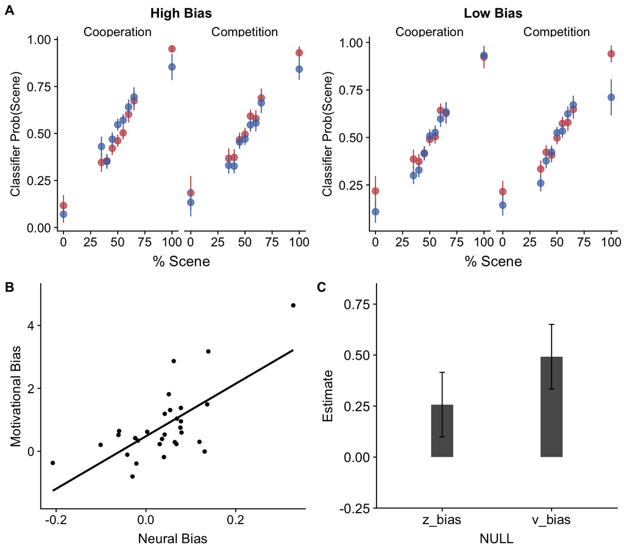

```r
lm.VVS.coef = lm.VVS$coefficients

# Extract coefficents
reg_coef = NULL
reg_coef$parm = c('z_bias','v_bias')
reg_coef$value = c(lm.VVS.coef["scale(z)","Estimate"],lm.VVS.coef["scale(drift_bias)","Estimate"])
reg_coef$SE = c(lm.VVS.coef["scale(z)","Std. Error"],lm.VVS.coef["scale(drift_bias)","Std. Error"])
reg_coef = as.data.frame(reg_coef)
reg_coef$parm = factor(reg_coef$parm, levels = c('z_bias','v_bias'))

# VVS ~ Z bias + V Bias
plot.VVS = ggplot(reg_coef) +
  geom_bar(aes(x = parm, y = value), stat = "identity", width = 0.2) +
  geom_errorbar(aes(x = parm, ymin = value - SE, ymax = value + SE), stat = "identity", width = 0.05) +
      theme(axis.text.x  = element_text(size=14,color="black"),
        axis.text.y  = element_text(size=14,color="black"),
        axis.title.y = element_text(size=14),
        strip.text.x = element_text(face = "bold", size = 14)) +
  ylab("Estimate") +
  xlab("NULL") +
  coord_cartesian(ylim=c(-0.2, 0.8))

# Plot all
plot_grid(plot.prob.bias,plot.prob.unbias,plot.prob.behav, plot.VVS, labels = c('A','','B', 'C'), ncol = 2)
```

**Motivation biases face and scene selective neural activity during visual categorization.** **A.** Classifier probability that the presented image was a scene rather than a face based on the BOLD response in the ventral visual stream, separately for participants with high and low behavioral bias. Blue dots: teammate or opponent betting that the next image will be scene; Red dots: teammate or opponent betting that the next image will be a face. For High Bias participants, scene probability was higher when participants were motivated to see a scene (i.e. teammate bets scene or opponent bets face) than when participants were motivated to see a face (i.e. teammate bets face or opponent bets scene). There was no effect of motivation in Low Bias participants. **B.** The effect of motivation on classifier probability (Neural Bias) was correlated with the extent to which a participant was bias in his or her categorizations (Motivational Bias). **C.** Regression coefficients of the response bias (βz) and perceptual bias (βv) when both were entered into the same model to predict participants’ neural bias. Only the perceptual bias was significantly associated with participants’ neural bias.